# ISE Analysis

J. Beem-Miller

17 April 2020

# Introduction

This notebook contains code for reading radiocarbon data from the Ice Storm Experiment (ISE). The ISE project was initiated by Prof. Tim Fahey at Cornell University at Arnot Forest, a northern hardwood research forest maintained by Cornell University near the main campus in upstate New York. Geographic coordinates for the site are: 42.26, -76.627 (obtained from google maps; these are not coordinates for the plots themselves).

# Background

*The following notes are drawn from information supplied by T. Fahey in the file:* “ise-fahey/data/external/ise_fahey_plot-IDs_2018-12-29/README.yaml”

Fahey and collaborators simulated the effect of an ice storm on a series of plots by spraying the canopy of mature forest plots with water during mid-winter of 2016. The treatments successfully damaged the canopies of the trees. The design included two replicate plots for each of four treatments: low, mid, high and mid 2x designating different levels of ice. “2x” plots were treated in two successive years, 2016 and 2017.

The hypothesis for the experiment is that canopy damage and subsequent recovery would result in reduced C supply and increased C demand, so that trees would need to draw on older C reserves to build fine roots following the treatment.

Data analyzed in this notebook come from fine roots sampled from ingrowth cores; the codes “O” and “M” are used for organic samples from the forest floor and samples from mineral soil, respectively. Roots analyzed were sampled in the second year of the experiment (2017). Nine ingrowth cores were collected per plot, which were pooled in the lab and then split into three lab replicates for analysis. Only data from the “high”, “mid2x”, and “control” treatments were analyzed.

# Results

Plotting the raw data by treatment (“Ctl” = control; “high” = high, treated in 2016 only; “mid2x” = mid level treatment applied in both 2016 and 2017) shows a potential treatment response in the mineral horizon samples (horizon = “M”), but no clear effect in the organic horizon samples. Overall, variability is high (Fig. 1, below).

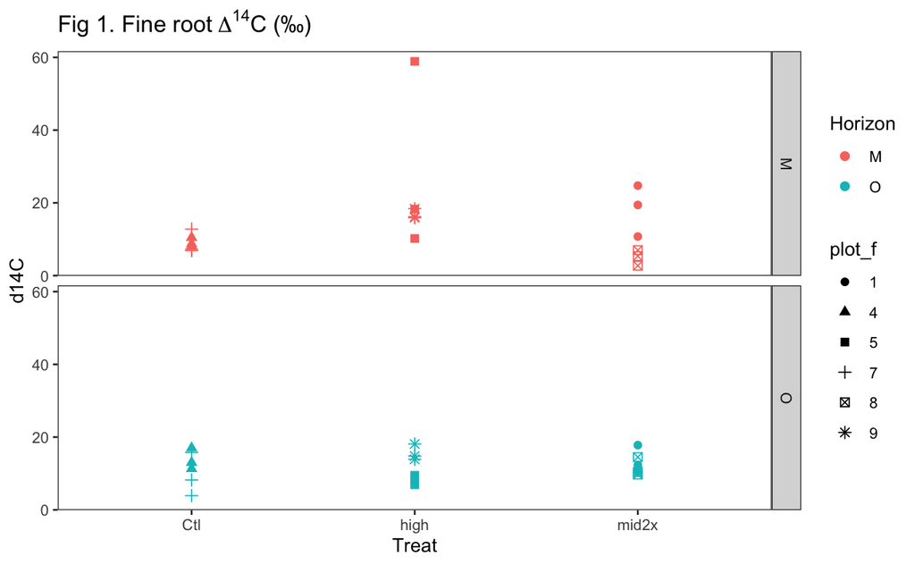

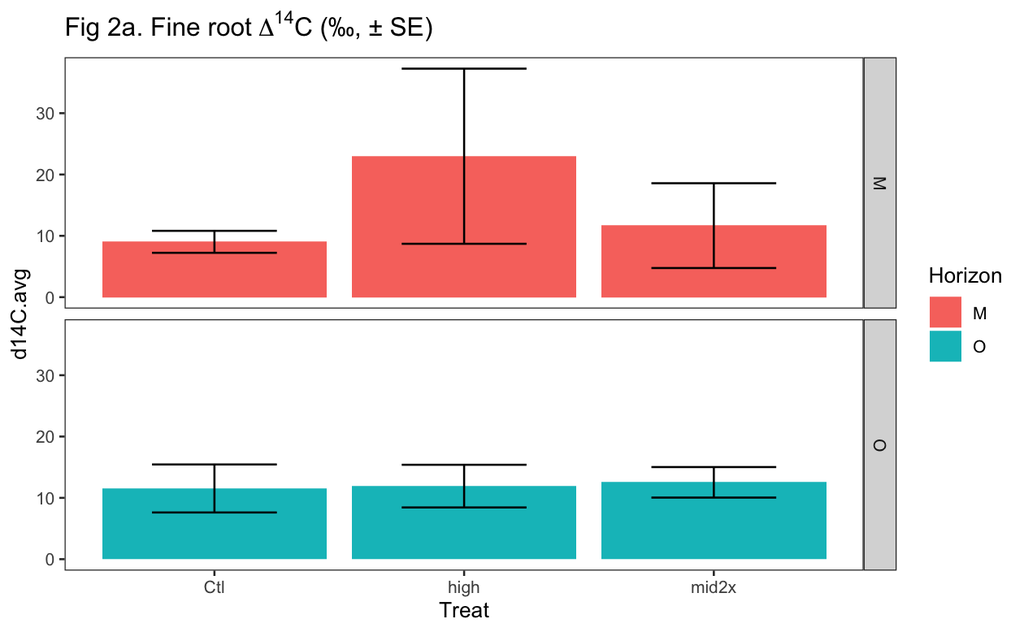

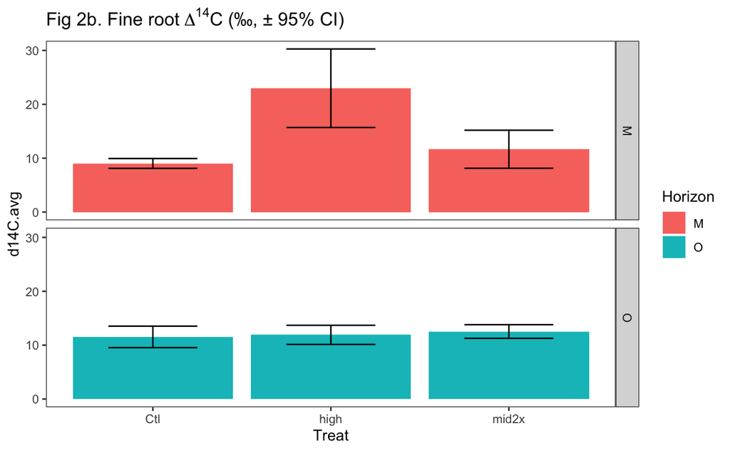

To assess the effect of individual plots, first we will create a variable representing the difference in $\Delta$<sup>14</sup>C between treatment and control samples, aggregated by plot.

Plotting the plot-level differences from the mean of the controls, by horizon, makes the differences appear more significant (Fig. 3a and 3b). However, with only three replicates per plot, perhaps these differences are not truly significant.

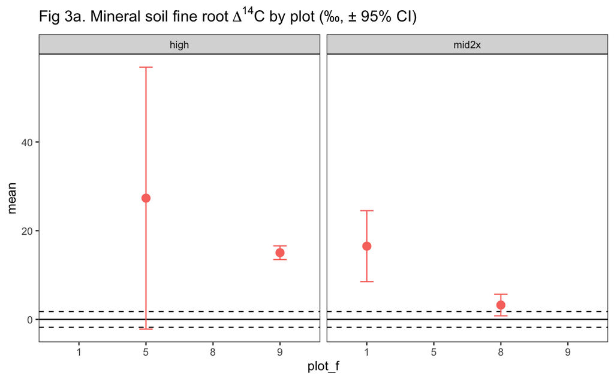

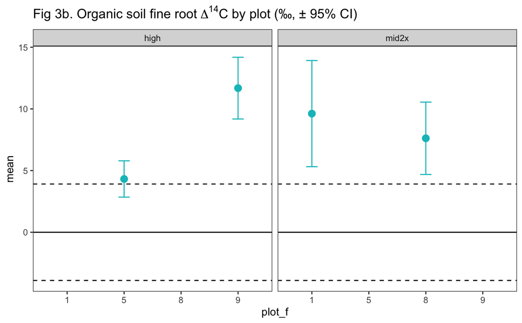

```
Call:
lm(formula = dif ~ Treat, data = ise[ise$Treat != "Ctl", ])

Residuals:
    Min      1Q  Median      3Q     Max
-11.611  -4.882  -1.759   1.483  42.511

Coefficients:
            Estimate Std. Error t value Pr(>|t|)
(Intercept)   14.596      3.160   4.620 0.000133 ***
Treatmid2x    -5.352      4.468  -1.198 0.243770
---
Signif. codes:  0 ‘***’ 0.001 ‘**’ 0.01 ‘*’ 0.05 ‘.’ 0.1 ‘ ’ 1

Residual standard error: 10.94 on 22 degrees of freedom
Multiple R-squared:  0.06121,   Adjusted R-squared:  0.01854
F-statistic: 1.435 on 1 and 22 DF,  p-value: 0.2438
```

Contrasts are also not significant:

```
non-factors ignored: Plotnon-factors ignored: Treat, Plot'which' specified some non-factors which will be dropped
```

```
  Tukey multiple comparisons of means
    95% family-wise confidence level

Fit: aov(formula = dif ~ Treat * Plot, data = ise)

$Treat
                diff        lwr       upr     p adj
high-Ctl    7.171927  -2.146084 16.489937 0.1568888
mid2x-Ctl   1.820198  -7.497813 11.138209 0.8805121
mid2x-high -5.351729 -14.669739  3.966282 0.3456746
```

```r
Anova(ise.mm.o) # ns
```

```
Analysis of Deviance Table (Type II Wald chisquare tests)

Response: d14C
       Chisq Df Pr(>Chisq)
Treat 0.1562  2     0.9249
```

# Conclusion

Overall, there is no evidence for treatment effects in the organic horizon samples, but some evidence of enrichment in mineral soil samples in response to treatment—especially the “high” damage treatment. The observed effect is in line with the hypothesis, i.e. mobilization of older (more enriched) carbon reserves in response to damage.